# Ptarmigan

[NO_PTAR_001]

Author

Affiliation

Anders Kolstad

The Norwegian Institute for Nature Research (NINA)

Published

June 23, 2026

> **Recommended citation**: Kolstad, A. 2026. Ptarmigan [Fjellrype] (ID(s): NO_PTAR_001) v. 1.0.0. ecRxiv: https://github.com/NINAnor/ecRxiv/tree/main/indicators/NO_PTAR_001

**Metadata**

Table 1: Indicator metadata

| Variable | Value |
| --- | --- |
| Indicator ID | NO_PTAR_001 |
| Indicator Name | Ptarmigan [Fjellrype] |
| verbatimName | Fjellrype |
| Country | Norway |
| Continent | Europe |
| Ecosystem Condition Typology Class | B1 - Compositional state characteristics |
| Realm | Terrestrial (T) |
| Biome | T6 Polar-alpine (cryogenic) biome |
| Ecosystem | NA |
| verbatimEcosystem | Fjell |
| Year added | 2026 |
| Last update | 2026 |
| Version | 1.0.0 |
| Version comment | First version on ecRxiv, but this indicator is already published and described in the Norwegian Nature Index |
| Normalised | TRUE |
| Spatial aggregation pathway | Aggregate (population model, county level) - [Scale - Truncate] - Aggregate (national level) |
| Precision | Uncertainties around the estimated true value reported as probability distributions and 95% confidence intervals. |

**Log**

- 16 Apr. 2026 - Original PR

## 1. Summary

1. **Background and rationale**: Rock ptarmigan (*Lagopus muta*) is a herbivorous alpine bird that is found throughout the Norwegian mountain range where it lives year round. It responds to anthropogenic disturbance, including climate change, through their effects on both survival and reporoduction. We also have a relatively good amount of data and knowledge about this species and the different populations. This combines to make ptarmigan a suitable indicator for ecosystem condition in Norwegian mountains. The species is also a popular game bird.
2. **Methods**: The ptarmigan population size is estimated from a statistical model, using hunting statistics as the main data source, and with the assumption that 10% of the population is shot each year. This value is then normalised based on a reference level, which is an expert-assessed population estimate based on known breeding density and the amount of suitable habitat. The indicator is developed in the work with the Norwegian Nature Index (Nater and Eriksen 2025). The methods are described in full on the [Nature index web site](https://www.naturindeks.no/Indicators/fjellrype).
3. **Interpretation**: An indicator value of 1 means that the ptarmigan is as numerous, or more, than what we expect under the reference condition. Values decreasing toward zero indicates that the average county-level population size is decreasing.
4. **Results and development needs**: The indicator value for 2024 for Norway as a whole is 0.35 (95% CI = 0.21 - 0.54), which indicates a relatively severe deviation from the reference condition. The development over time is showing a negative trend.

## 1.2 Native language summary - Norwegian

1. **Bakgrunn og begrunnelse**: Rype (*Lagopus muta*) er en hønsefugl som finnes over hele den norske fjellkjeden, hvor den lever hele året. Arten er følsom på menneskeskapte forstyrrelser, inkludert klimaendringer, gjennom deres effekter på både overlevelse og reproduksjon. Vi har relativt gode mengder data og kunnskap om denne arten og de ulike bestandene. Dette gjør rypa til en egnet indikator for økologisk tilstand i norske fjellområder. Arten er også en populær jaktfugl og reguleres delvsis gjennom kvotesettingen.
2. **Metoder**: Bestandsstørrelsen av rype estimeres ved hjelp av en statistisk modell, der jaktstatistikk er hoveddatakilden. Det brukes en antakelse om at 10 % av bestanden skytes hvert år. Denne verdien normaliseres deretter basert på en referanseverdi, som er et ekspertvurdert bestandsestimat basert på kjent hekketetthet og mengden egnet habitat. Indikatoren er utviklet i arbeidet med Naturindeksen (Nater and Eriksen 2025). Metodene er beskrevet i detalj på [Naturindeksens nettsider](https://www.naturindeks.no/Indicators/fjellrype).
3. **Tolkning**: En indikatorverdi på 1 betyr at rypebestanden er like stor eller større enn det vi forventer under referansetilstanden. Verdier som nærmer seg null indikerer at den gjennomsnittlige bestandsstørrelsen på fylkesnivå er avtagende.
4. **Resultater og utviklingsbehov**: Indikatorverdien for 2024 for Norge er 0,35 (95 % KI = 0,21–0,54), noe som indikerer et relativt stort avvik fra referansetilstanden. Utviklingen over tid viser en negativ trend.

## 2. About the underlying data

The data comes from hunting statistics (harvest bag data) published by SSB (Statistics Norway). The procedure to download the data is described [here](https://naturindeks.nina.no/docs/24dda0ba-5855-4131-9168-d874980ec6aa.pdf).

### 2.1 Spatial and temporal resolution and extent

Indicator values are available for the different assessment years in *Naturindeksen*: 1990, 2000, 2010, 2011, 2012, 2013, 2014, 2019 and 2024. To produce indicator estimates for these years, one uses the average over 2-3 year. For the year 2024, data from two hunting seasons were included (2022/23-2023/24).

The indicator is calculated for all counties in Norway. Here we report the values for five geographic regions, and for Norway as a whole.

### 2.2 Sampling design

The data originates from hunters when they report their catches, something they are required to do. The sampling/hunting effort is not known, and assumed to be stable. This is a rather big assumption.

### 2.3 Original units

The original units of the raw data is the number of individuals. The data are assigned to spatial units, so this could be turned into measures of density.

### 2.4 Instructions for citing, using and accessing data

The underlying data (hunting statistics) are available via SSB, but not in a prepared format (see [here](https://naturindeks.nina.no/docs/24dda0ba-5855-4131-9168-d874980ec6aa.pdf)).

Indicator point estimates and quantiles, for different geographic units, are freely available (Nater et al. 2025).

## 3. Indicator properties

### 3.1 Ecosystem Condition Typology Class (ECT)

B1 - Compositional state characteristics

### 3.2 Ecosystem condition characteristic

The ecosystem characteristic represented in this indicator is an ecosystem where species abundances and composition is similar to that in the reference condition.

### 3.3 Collinearities with other indicators

The indicator might be correlated to other indicators, especially other indicators within ECT class B1, such as the species that prey on ptarmigan (arctic fox, golden eagle), or other species that have similar habitats or way of live (such as willow grouse).

### 3.4 Impact factors

Ptarmigan is sensitive to several antropogenic pressures, especially climate change and hunting, but also habitat destruction and disturbance by human activities.

### 3.5 Spatial aggregation

The hunting statistics are aggregated to county level using a population model. There the variable value is normalised by scaling and truncating against X<sub>100</sub> and X<sub>0</sub>. The indicator values are then resampled to five geographic regions, and then to Norway, with a sampling weight proportional to the mountain area in each region or area.

## 4. Reference condition and levels

### 4.1 Reference condition

The reference condition is a moutain ecosystem with minimal human impact and a climate similar to the period 1961-1990 (Nybø and Evju (red) 2017).

### 4.2 Reference levels

X<sub>100</sub> is defined based on the predicted number of ptarmigan individuals based on a statistical model. This value varies between counties.

X<sub>0</sub> is defined as a complete absence of ptarmigan.

X<sub>60</sub> is not specified and defaults to 60% of the X<sub>100</sub> value.

#### 4.2.1 Spatial resolution and validity

The reference values vary with counties, and normalisation of variable values should be done after aggregating those first to the same county scale.

## 5. Uncertainties

### 5.1 General uncertainties

There are obvious limitations to using harvest bag data, rather than more standardised monitoring data. This is elaborated in the [indicator documentation on Naturindeksen](https://naturindeks.nina.no/docs/24dda0ba-5855-4131-9168-d874980ec6aa.pdf). However, we feel the hunting data still has considerable value and that it is indeed suitable for this purpose of estimating population sizes.

## 6. References

Nater, C. R., and L. F. Eriksen. 2025. *Naturindeks for Norge 2025. Tilstand og utvikling for biologisk mangfold.* {NINA} {Temahefte} 97. Trondheim: Norsk Institutt for Naturforskning.

Nater, C. R., T. Zeiner-Henriksen, and S. Nybø. 2025. NI2025: Indicator Data. doi:10.21345/y790-v762.

Nybø, S., and M. Evju (red). 2017. *[Fagsystem for fastsetting av god økologisk tilstand - forslag fra et ekspertråd](https://www.regjeringen.no/no/dokumenter/fagsystem-for-fastsetting-av-god-okologisk-tilstand/id2558481/)*.

## 7. Import and prepare datasets

### 7.1 Naturindeks

We download the dataset from the Naturindeks database using the API.

```r
# password is hidden for now, but the plan is to set up a read only guest access. Therefore I upload thh database export to github for now to ensure reproducibility.
source(here::here("R", "_pw.R"))

# Import data set
ptarImport <- NIcalc::importDatasetApi(
  username = myUser,
  password = myPwd,
  eco = NULL,
  indic = c("Fjellrype"),
  year = c("2010", "2014", "2019", "2024")
)
saveRDS(ptarImport, here::here("data/ptarImport.rds"))
```

## 9. Analyses

Here I use a generic approach to handling data from the Naturindeks where I get both the variable values and the reference values, separately, from the NI database, and perform the normalisation and spatial aggregation ourselves.

The reference values have uncertainties attached to them, which we will ignore here. The variable values have uncertainties as well, in the form of probability function. The uncertainties are from a statistical model, and so we think of them as inferential uncertainties.

Here I use an NIcalc function to just prepare and structure the data a little differently.

```r
# Assemble
ptarAssemble <- NIcalc::assembleNiObject(
  inputData = ptarImport,
  predefNIunits = c(allArea = T, parts = T, counties = F),
  indexType = "thematic"
)
```

```
Check input data .....
```

```
Elicitate incomplete reference values and indicator observations .....
```

```
Assemble dataset .....
```

Then I get the reference values. These are unique to each county (ICunit). I only have an X<sub>100</sub> value. X<sub>0</sub> is a natural zero.

```r
x100 <- ptarImport$referenceValues$referenceValues |>
  select(ICunitId, ICunitName, x100 = expectedValue)
x100
```

```
# A tibble: 15 × 3
   ICunitId ICunitName        x100
      <int> <chr>            <dbl>
 1     1391 Hedmark           49.3
 2     1392 Oppland          114.
 3     1393 Buskerud          42.3
 4     1394 Telemark          38.6
 5     1395 Aust-Agder        19.7
 6     1396 Vest-Agder        17.7
 7     1397 Rogaland          37.6
 8     1398 Hordaland         97.5
 9     1399 Sogn og Fjordane 116.
10     1400 Møre og Romsdal   72.8
11     1401 Sør-Trøndelag     62.0
12     1402 Nord-Trøndelag    63.0
13     1403 Nordland         213.
14     1404 Troms            178.
15     1405 Finnmark         299.
```

The variable values are stored as a parameterised probability function, and I need to draw *n* samples from this function. The probability function differs between indicators in the Naturindeks. It could also differ within an indicator. Here I create a vector defining which probability function to use. I use ´tradObs´ where there is a regular probability distribution family, and `customObs` where customDist!= NA. When `distributionFamilyName == NA`, `customDistribution != NA`.

```r
myYears <- as.character(c(2010, 2014, 2019, 2024))
obstype <- NULL

for (i in 1:length(myYears)) {
  obs <- ptarAssemble$indicatorValues[[i]]$distributionFamilyName

  obs[!is.na(obs)] <- "tradObs"
  obs[is.na(obs)] <- "customObs"

  obstype[[i]] <- obs
}
```

Now I am ready to sample the probability distributions. I set *n* to be 1000.

```r
dat <- tibble(ICunitId = NULL, value = NULL, year = NULL)

for (i in 1:length(myYears)) {
  #print(i)
  myMat <- NIcalc::sampleObsMat(
    ICunitId = ptarAssemble$indicatorValues[[i]]$ICunitId,
    value = ptarAssemble$indicatorValues[[i]]$expectedValue,
    distrib = ptarAssemble$indicatorValues[[i]]$distributionFamilyName,
    mu = ptarAssemble$indicatorValues[[i]]$distParameter1,
    sig = ptarAssemble$indicatorValues[[i]]$distParameter2,
    customDistribution = ptarAssemble$indicatorValues[[i]]$customDistribution,
    obsType = obstype[[i]],
    nsim = 1000
  )
  ICunitIds <- row.names(myMat)

  myMat <-  myMat |>
    as_tibble() |>
    add_column(ICunitId = ICunitIds, .before = 1) |>
    pivot_longer(cols = -any_of("ICunitId")) |>
    select(-name) |>
    add_column(year = myYears[i])

  dat <- dat |>
    bind_rows(myMat)
}
head(dat)
```

```
# A tibble: 6 × 3
  ICunitId value year
  <chr>    <dbl> <chr>
1 1391     11.5  2010
2 1391     19.3  2010
3 1391     37.2  2010
4 1391      4.68 2010
5 1391     17.6  2010
6 1391      9.41 2010
```

This is the point in the spatial aggregation where we should normalise against the reference values. So let’s add inn the X100 values.

```r
dat <- dat |>
  left_join(x100 |> mutate(ICunitId = as.character(ICunitId)), by = join_by(ICunitId))
```

Then we can normalise also the scatter plot with variables against indicator values (Figure 1).

```r
ind <- ec_normalise(
  variable = dat$value,
  x100 = dat$x100
)

dat <- dat |> add_column(indicator = ind)
```

```r
temp <- ec_norm_plot(dat$value, dat$indicator) +
  facet_wrap(.~dat$ICunitName)
ggsave(here::here("img/norm_plot_eng.png"), scale =1.5, plot =temp)
```

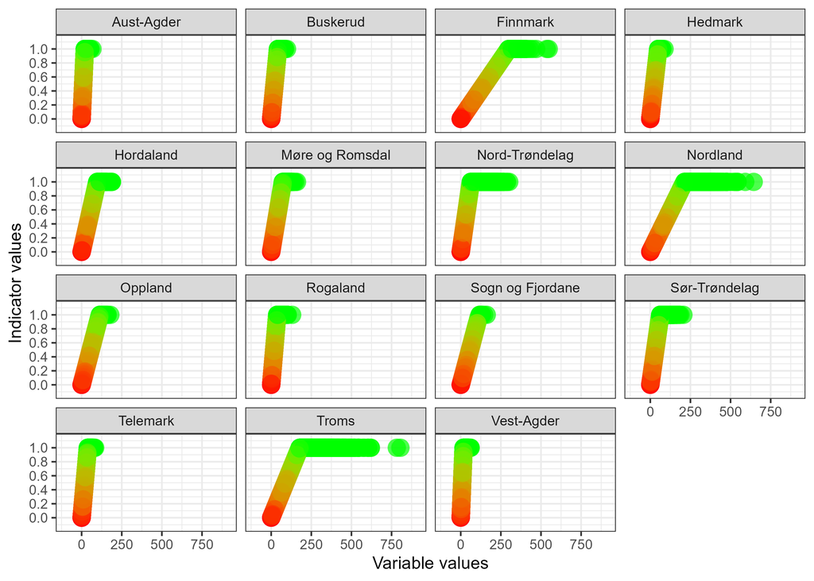

Figure 1: Normalisation (scaling and truncation) of variable values into indicator values. The X100 value differs between 15 counties in Norway.

```r
knitr::include_graphics(here::here("img/norm_plot_eng.png"))
```

I also export a figure for the Norwegian fact sheet:

**Export normalisation function plots**

```r
temp <- ec_norm_plot(dat$value, dat$indicator, lan = "norsk") +
  facet_wrap(.~dat$ICunitName)
ggsave(here::here("img/norm_plot_facet.png"), scale =1.5, plot =temp)

temp <- ec_norm_plot(dat$value, dat$indicator, lan = "norsk")
ggsave(here::here("img/norm_plot.png"), scale =1, plot =temp)
```

```r
# In this object we get the rows per municipality (BSunits), with mountain area ("Fjell") and geographic region ("part").
aux <- as_tibble(ptarAssemble$BSunits) |>
  rename(BSunitId = id)
head(aux)
```

```
# A tibble: 6 × 10
  BSunitId Fjell name        totalArea terrestrialArea marineArea county  part
     <int> <dbl> <chr>           <dbl>           <dbl>      <dbl> <chr>   <chr>
1      428  255. Trysil          3017.           3017.          0 Hedmark E
2      430  386. Stor-Elvdal     2171.           2171.          0 Hedmark E
3      432  800. Rendalen        3180.           3180.          0 Hedmark E
4      434  550. Engerdal        2198.           2198.          0 Hedmark E
5      436  462. Tolga           1124.           1124.          0 Hedmark E
6      437  644. Tynset          1880.           1880.          0 Hedmark E
# ℹ 2 more variables: centerLat <dbl>, centerLong <dbl>
```

The data is at the ICunit level (counties) so wee need to add the ICunitId into here.

```r
IC_BC_link <- ptarImport$ICunits |>
  select(ICunitId = id, BSunitId)

aux <- aux |>
  left_join(IC_BC_link, by = join_by(BSunitId))
```

Then we can sum the mountain area, and move that value, and the geographic region, into the main dataset. We use the alpine area that is recorded in the Naturindeks database. They should represenet the area above the empirical forest line.

```r
aux <- aux |>
  group_by(ICunitId) |>
  summarise(alpine_area = sum(Fjell), part = unique(part)) |>
  mutate(ICunitId = as.character(ICunitId))

dat <- dat |>
  left_join(aux, by = join_by(ICunitId))
```

### Spatial aggregation

Then aggregate from counties to geographic regions using ecTools. This uses a Monte Carlo propagation of the uncertainties.

```r
mc_propagated <- ecTools::ec_upscale(
  data = dat,
  variable = indicator,
  weight = alpine_area,
  start_units = ICunitId,
  end_units = part,
  year = year,
  end_units_name = "part",
  n = 1000
)
saveRDS(mc_propagated, here::here("data/mc_propagated.rds"))
```

To get the national indicator estimate, we will do another MC propagation from geographic regions to national scale. So we need the summed mountain area per geographic region.

```r
aux2 <- aux |>
  group_by(part) |>
  summarise(alpine_area = sum(alpine_area))
aux2
```

```
# A tibble: 5 × 2
  part  alpine_area
  <chr>       <dbl>
1 C          16077.
2 E          17373.
3 N          56122.
4 S           6368.
5 W          18503.
```

```r
mc_propagated <- mc_propagated |>
  left_join(aux2, by = join_by(part)) |>
  add_column(end_units = "Norway")

mc_propagated2 <- ecTools::ec_upscale(
  data = mc_propagated,
  variable = sampled_mean,
  weight = alpine_area,
  start_units = part,
  end_units = end_units,
  year = year,
  end_units_name = "part",
  n = 1000
)
saveRDS(mc_propagated2, here::here("data/mc_propagated2.rds"))
```

Then we append this to the main dataset

```r
mc_propagated3 <- mc_propagated |>
  select(year, part, sampled_mean) |>
  bind_rows(mc_propagated2)
```

## 10. Results

Then we create some summary statistics (Table 2) and plot them (Figure 2).

```r
summary_out <- mc_propagated3 |>
  group_by(part, year) |>
  summarise(
    median = round(median(sampled_mean), 2),
    p_025 = round(quantile(sampled_mean, probs = 0.025), 2),
    p_25 = round(quantile(sampled_mean, probs = 0.25), 2),
    p_75 = round(quantile(sampled_mean, probs = 0.75), 2),
    p_975 = round(quantile(sampled_mean, probs = 0.975), 2),
  ) |>
  add_column(
    ECT = "B1",
    Indicator = "Ptarmigan",
    Ecosystem = "Mountains",
    ID = "NO_PTAR_001"
  )
```

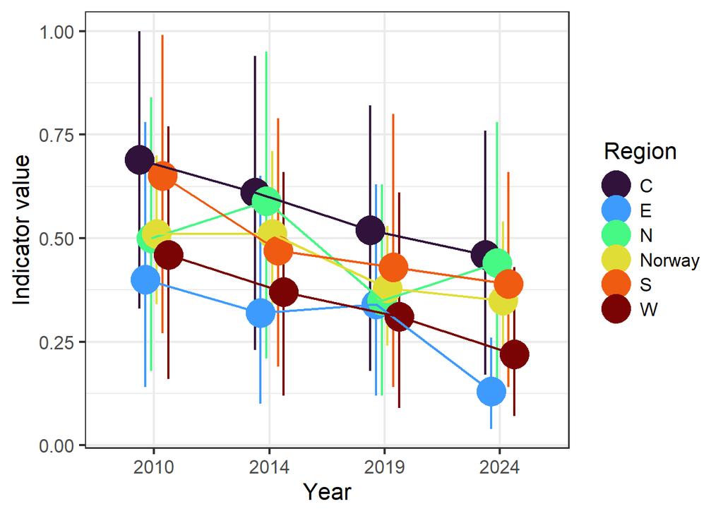

Figure 2: Indicator values for NO_PTAR_001 (ptarmigan) plotted over time and for five different regions, as well as the combined national estimated. The error bars are 95% confidence intervals.

```r
summary_out |>
  ggplot(aes(x = year, y = median, colour = part, group = part)) +
  geom_pointrange(
    aes(ymin = p_025, ymax = p_975),
    size = 2,
    position = position_dodge(width = 0.3)
  ) +
  geom_line(position = position_dodge(width = 0.3)) +
  theme_bw(base_size = 16) +
  labs(y = "Indicator value", x = "Year") +
  scale_colour_viridis_d(option = "turbo", name = "Region")
```

```r
summary_out |>
  unite(col = "CI_95", c(p_025, p_975), sep = " - ") |>
  unite(col = "IQR", c(p_25, p_75), sep = " - ") |>
  select(
    ECT,
    Indicator,
    ID,
    "Accounting area" = part,
    Ecosystem,
    "Closing year" = year,
    "Indicator value" = median,
    "95% CI" = CI_95,
    "50% CI" = IQR
  ) |>
  kable()
```

Table 2: Indicator values and uncertainty estimates for NO_PTAR_001.

| ECT | Indicator | ID | Accounting area | Ecosystem | Closing year | Indicator value | 95% CI | 50% CI |
| --- | --- | --- | --- | --- | --- | --- | --- | --- |
| B1 | Ptarmigan | NO_PTAR_001 | C | Mountains | 2010 | 0.69 | 0.33 - 1 | 0.55 - 0.81 |
| B1 | Ptarmigan | NO_PTAR_001 | C | Mountains | 2014 | 0.61 | 0.23 - 0.94 | 0.49 - 0.74 |
| B1 | Ptarmigan | NO_PTAR_001 | C | Mountains | 2019 | 0.52 | 0.18 - 0.82 | 0.41 - 0.65 |
| B1 | Ptarmigan | NO_PTAR_001 | C | Mountains | 2024 | 0.46 | 0.17 - 0.76 | 0.35 - 0.57 |
| B1 | Ptarmigan | NO_PTAR_001 | E | Mountains | 2010 | 0.40 | 0.14 - 0.78 | 0.29 - 0.53 |
| B1 | Ptarmigan | NO_PTAR_001 | E | Mountains | 2014 | 0.32 | 0.1 - 0.65 | 0.23 - 0.43 |
| B1 | Ptarmigan | NO_PTAR_001 | E | Mountains | 2019 | 0.34 | 0.12 - 0.63 | 0.26 - 0.45 |
| B1 | Ptarmigan | NO_PTAR_001 | E | Mountains | 2024 | 0.13 | 0.04 - 0.26 | 0.09 - 0.17 |
| B1 | Ptarmigan | NO_PTAR_001 | N | Mountains | 2010 | 0.50 | 0.18 - 0.84 | 0.38 - 0.62 |
| B1 | Ptarmigan | NO_PTAR_001 | N | Mountains | 2014 | 0.59 | 0.21 - 0.95 | 0.45 - 0.72 |
| B1 | Ptarmigan | NO_PTAR_001 | N | Mountains | 2019 | 0.35 | 0.12 - 0.63 | 0.25 - 0.44 |
| B1 | Ptarmigan | NO_PTAR_001 | N | Mountains | 2024 | 0.44 | 0.15 - 0.78 | 0.32 - 0.56 |
| B1 | Ptarmigan | NO_PTAR_001 | Norway | Mountains | 2010 | 0.51 | 0.34 - 0.7 | 0.45 - 0.57 |
| B1 | Ptarmigan | NO_PTAR_001 | Norway | Mountains | 2014 | 0.51 | 0.31 - 0.71 | 0.44 - 0.58 |
| B1 | Ptarmigan | NO_PTAR_001 | Norway | Mountains | 2019 | 0.38 | 0.24 - 0.53 | 0.32 - 0.43 |
| B1 | Ptarmigan | NO_PTAR_001 | Norway | Mountains | 2024 | 0.35 | 0.21 - 0.54 | 0.3 - 0.41 |
| B1 | Ptarmigan | NO_PTAR_001 | S | Mountains | 2010 | 0.65 | 0.27 - 0.99 | 0.51 - 0.79 |
| B1 | Ptarmigan | NO_PTAR_001 | S | Mountains | 2014 | 0.47 | 0.19 - 0.79 | 0.36 - 0.58 |
| B1 | Ptarmigan | NO_PTAR_001 | S | Mountains | 2019 | 0.43 | 0.14 - 0.8 | 0.32 - 0.57 |
| B1 | Ptarmigan | NO_PTAR_001 | S | Mountains | 2024 | 0.39 | 0.14 - 0.66 | 0.29 - 0.48 |
| B1 | Ptarmigan | NO_PTAR_001 | W | Mountains | 2010 | 0.46 | 0.16 - 0.77 | 0.34 - 0.57 |
| B1 | Ptarmigan | NO_PTAR_001 | W | Mountains | 2014 | 0.37 | 0.12 - 0.66 | 0.26 - 0.46 |
| B1 | Ptarmigan | NO_PTAR_001 | W | Mountains | 2019 | 0.31 | 0.09 - 0.61 | 0.22 - 0.4 |
| B1 | Ptarmigan | NO_PTAR_001 | W | Mountains | 2024 | 0.22 | 0.07 - 0.43 | 0.17 - 0.29 |

## 11. Export file

The indicator values are exported and can be found under `data/results_NO_PTAR_001_v1.0.0.csv`.

**Export data**

```r
write.csv(mc_propagated, here::here("data/results_NO_PTAR_001_v1.0.0.csv"), row.names = F)
```

## 12. Author contributions

Not relevant, as this is the work of a single author. I would, however, like to acknowledge the work of those that created the indicator on *Naturindeks* (Nater and Eriksen 2025).

**Session Info**

This workflow uses `renv`. Run `renv::restore()` to recreate the working environment.